# Internet Access in Multnomah County

Charles Hanks

# Introduction

Suppose my client is the Multnomah County Library (MCL), which operates 19 library branches across Portland.

Following the approval by voters in 2020 of Measure 26-211, the county is funding renovation of 8 of the 19 libraries and creating a new flagship library at 7905 SE Holgate to serve East Portlanders.

As our daily lives have become increasingly digital, access to adequate information technology has become a necessity. The COVID-19 pandemic accelerated this shift, where video conferencing became the norm for so many of us to go to school, the doctor, and work. However, not everyone has access to the internet at home. Our library system is one solution to provide access to information technology to everyone at no cost. MCL has asked that I provide a report addressing the following questions:

-Where in Multnomah County is there the most people without broadband internet access at home? -Are the libraries’ locations conveient for those who need access to information technology?  
-Who will benefit most from the new flagship library on SE Holgate?

I used the 2021 American Community Survey to answer who how many people not have have access to the internet at home, where they live, and created visualization to present my findings to the Library Advisory Board.

## My Findings

- Over 20,000 people in Multnomah County do not have access to broadband internet at home.
- The largest concentrations of people without internet at home are in Downtown (15.6%) and Old Town Portland (17.5%), followed by the Piedmont Neighborhood (8%).
- With the Central Library closed for renovations through the end of 2023 at the earliest, there is currently no access to the internet in Downtown Portland, whose residents benefit the most from MCL’s technological resources.
- MCL plans to open a pop-up technology resource center at 510 SE Washington, however no opening date has been announced.

```r
library(tidyverse)
```

```r
library(maps)
library(sf)
library(tigris)
library(tidycensus)
library(tmap)
library(leaflet)
```

Loading the American Community Survey data from the Census bureau:

```r
#grabbing variables from 2021 ACS 1-year estimates (data collected Jan 1 2021 - Dec 31 2021)
acs_vars_2021 = load_variables(year = 2021, dataset = "acs1")

#searching for variables with internet
acs_vars_2021 %>% filter(grepl("internet", concept, ignore.case = T)) #| grepl("computer", concept, ignore.case = T))
```

| name | label | concept |
| --- | --- | --- |
| B28002_001 | Estimate!!Total: | PRESENCE AND TYPES OF INTERNET SUBSCRIPTIONS IN HOUSEHOLD |
| B28002_002 | Estimate!!Total:!!With an Internet subscription | PRESENCE AND TYPES OF INTERNET SUBSCRIPTIONS IN HOUSEHOLD |
| B28002_003 | Estimate!!Total:!!With an Internet subscription!!Dial-up with no other type of Internet subscription | PRESENCE AND TYPES OF INTERNET SUBSCRIPTIONS IN HOUSEHOLD |
| B28002_004 | Estimate!!Total:!!With an Internet subscription!!Broadband of any type | PRESENCE AND TYPES OF INTERNET SUBSCRIPTIONS IN HOUSEHOLD |
| B28002_005 | Estimate!!Total:!!With an Internet subscription!!Cellular data plan | PRESENCE AND TYPES OF INTERNET SUBSCRIPTIONS IN HOUSEHOLD |
| B28002_006 | Estimate!!Total:!!With an Internet subscription!!Cellular data plan!!Cellular data plan with no other type of Internet subscription | PRESENCE AND TYPES OF INTERNET SUBSCRIPTIONS IN HOUSEHOLD |
| B28002_007 | Estimate!!Total:!!With an Internet subscription!!Broadband such as cable, fiber optic or DSL | PRESENCE AND TYPES OF INTERNET SUBSCRIPTIONS IN HOUSEHOLD |
| B28002_008 | Estimate!!Total:!!With an Internet subscription!!Broadband such as cable, fiber optic or DSL!!Broadband such as cable, fiber optic or DSL with no other type of Internet subscription | PRESENCE AND TYPES OF INTERNET SUBSCRIPTIONS IN HOUSEHOLD |
| B28002_009 | Estimate!!Total:!!With an Internet subscription!!Satellite Internet service | PRESENCE AND TYPES OF INTERNET SUBSCRIPTIONS IN HOUSEHOLD |
| B28002_010 | Estimate!!Total:!!With an Internet subscription!!Satellite Internet service!!Satellite Internet service with no other type of Internet subscription | PRESENCE AND TYPES OF INTERNET SUBSCRIPTIONS IN HOUSEHOLD |

[output cut: 193 more lines]

```r
#looks like I will need to take into account the population per tract in order to calculate percent of those without internet at home.
acs_vars_2021 %>% filter(grepl("population", concept, ignore.case = T))
```

| name | label | concept |
| --- | --- | --- |
| B01003_001 | Estimate!!Total | TOTAL POPULATION |
| B05006_001 | Estimate!!Total: | PLACE OF BIRTH FOR THE FOREIGN-BORN POPULATION IN THE UNITED STATES |
| B05006_002 | Estimate!!Total:!!Europe: | PLACE OF BIRTH FOR THE FOREIGN-BORN POPULATION IN THE UNITED STATES |
| B05006_003 | Estimate!!Total:!!Europe:!!Northern Europe: | PLACE OF BIRTH FOR THE FOREIGN-BORN POPULATION IN THE UNITED STATES |
| B05006_004 | Estimate!!Total:!!Europe:!!Northern Europe:!!Denmark | PLACE OF BIRTH FOR THE FOREIGN-BORN POPULATION IN THE UNITED STATES |
| B05006_005 | Estimate!!Total:!!Europe:!!Northern Europe:!!Ireland | PLACE OF BIRTH FOR THE FOREIGN-BORN POPULATION IN THE UNITED STATES |
| B05006_006 | Estimate!!Total:!!Europe:!!Northern Europe:!!Norway | PLACE OF BIRTH FOR THE FOREIGN-BORN POPULATION IN THE UNITED STATES |
| B05006_007 | Estimate!!Total:!!Europe:!!Northern Europe:!!Sweden | PLACE OF BIRTH FOR THE FOREIGN-BORN POPULATION IN THE UNITED STATES |
| B05006_008 | Estimate!!Total:!!Europe:!!Northern Europe:!!United Kingdom (inc. Crown Dependencies): | PLACE OF BIRTH FOR THE FOREIGN-BORN POPULATION IN THE UNITED STATES |
| B05006_009 | Estimate!!Total:!!Europe:!!Northern Europe:!!United Kingdom (inc. Crown Dependencies):!!United Kingdom, excluding England and Scotland | PLACE OF BIRTH FOR THE FOREIGN-BORN POPULATION IN THE UNITED STATES |

[output cut: 9990 more lines]

Potenial variables to use:

B01003_001 total population B28002_013 no internet access B28002_004 with broadband of any type B28003_006 no computer B28003_004 has computer with broadband internet B01003_001 total population

```r
this.year = 2021

#downloading census tract shapefile of multnomah county
or_tracts = tracts(state = 'OR', county = 'Multnomah', cb = TRUE, year = this.year)

pop_and_no_internet = get_acs(geography = "tract", year=this.year,
              state = "OR", county = "Multnomah",
              variables = c(total_pop = "B01003_001",
                            no_internet = "B28002_013")) %>%
                    mutate(AFFGEOID=paste0("1400000US", GEOID)) #creating AFFGEOID id from GEOID in order to join data to tract spatial data
pop_no_int = as.data.frame(pop_and_no_internet)[,c(1,3:4)] %>%
    pivot_wider(names_from = variable, values_from = estimate) %>% #making the data frame tidy
      mutate(perc_no_int = round((no_internet/total_pop)*100,2), #creating variable that is percentage of population in tract that does not have internet
              AFFGEOID=paste0("1400000US", GEOID))

#summary data
pop_no_int %>% drop_na() %>% summarize(sum_pop = sum(total_pop), sum_no_internet = sum(no_internet))
```

| sum_pop | sum_no_internet |
| --- | --- |
| 810011 | 20800 |

```r
pop_no_int %>% arrange(desc(perc_no_int))
```

| GEOID | total_pop | no_internet | perc_no_int | AFFGEOID |
| --- | --- | --- | --- | --- |
| 41051005103 | 2302 | 402 | 17.46 | 1400000US41051005103 |
| 41051010601 | 1530 | 240 | 15.69 | 1400000US41051010601 |
| 41051010602 | 1966 | 161 | 8.19 | 1400000US41051010602 |
| 41051003701 | 4360 | 355 | 8.14 | 1400000US41051003701 |
| 41051008203 | 5923 | 409 | 6.91 | 1400000US41051008203 |
| 41051010410 | 4430 | 296 | 6.68 | 1400000US41051010410 |
| 41051010001 | 6295 | 408 | 6.48 | 1400000US41051010001 |
| 41051002702 | 3600 | 229 | 6.36 | 1400000US41051002702 |
| 41051002402 | 3178 | 199 | 6.26 | 1400000US41051002402 |
| 41051005102 | 3013 | 182 | 6.04 | 1400000US41051005102 |

[output cut: 187 more lines]

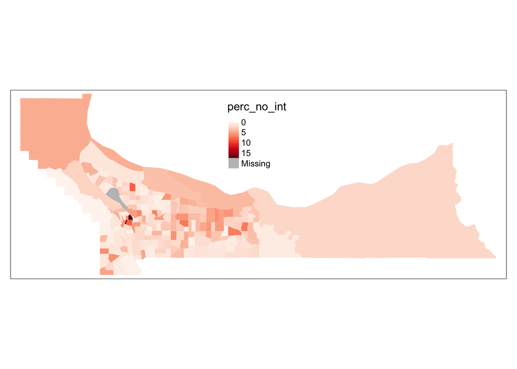

```r
# GEOIDs 41051005103 has estimated 17 % no internet at home, 41051010601 has almost 16%


#joining this ACS data with tract spatial data
pop_no_int_tracts = geo_join(or_tracts, pop_no_int, by_sp = "AFFGEOID", by_df = "AFFGEOID")
#first visualization using
tm_shape(pop_no_int_tracts) +
  tm_fill("perc_no_int", style = "cont", palette = "Reds") +
  tm_legend(bg.color = "white", bg.alpha = 0.6, position = c("center", "top"))
```

```r
#Tthe dark red tracts must be 41051005103 and 41051010601. I cannot tell where that is geographically in the county.
```

Creating an interactive graphic using leaflet:

```r
pal<-colorNumeric("Reds", domain=0:ceiling(max(pop_no_int_tracts$perc_no_int, na.rm=TRUE)))

popup<-paste("Tract: ", as.character(substring(pop_no_int_tracts$GEOID.x, 6, 11)), "<br>",
             "Percentage of Households without broadband internet: ", as.character(pop_no_int_tracts$perc_no_int))

library(leafletCN)


leaflet()%>%
  addProviderTiles("CartoDB.Positron")%>%
  addPolygons(data=pop_no_int_tracts,
              fillColor= ~pal(pop_no_int_tracts$perc_no_int),
              fillOpacity = .5,
              weight =.5,
              smoothFactor = 0.2,
              popup = popup) %>%
  addMarkers(lat = 45.519702018355936, lng = -122.6831405693095, popup = "Multnomah County\nCentral Library") %>%
  addMarkers(lat = 45.582959138612935, lng = -122.68644127317535, popup = "Multnomah County Library - Kenton") %>%
  addControl(
    position = "bottomright",
    html = "<h4>Households without Access to the Internet in Multnomah County</h4>"
  )
```

[interactive chart not shown]